# Machine Learning Assignment

Pat O’Keeffe

26 February 2018

## Executive Summary

The goal of your project is to predict the manner in which people did exercise using health monitoring data collected from a sample of people. The indicator is defined by the “classe” variable. Any other variables in the dataset may be used to build a prediction model which will be used to predict the “classe” variable for the testing dataset comprising 20 observations.

## Model Design Approach

Two datasets were provided as follows:

- pml-training.csv

This data set comprises 19622 observations of 160 Variables.

- pml-testing.csv

This data set comprises 20 observations of 160 variables where classe is not defined and will be predicted by the model.

For the purposes of building and validating the model the provided traninig set was further divided into a training and test set of it’s own. 75% of the observations were stored in the sub-training set and the remaining in the sub-test set.

## Environment Setup

First we will load the required libraries, set the working directory and load the data.

## Cross Validation & Predictor Reduction

A key step before spliting the training dataset is to use set.seed to ensure the results are reproduceable. Then we split the data for the purposese of cross validation.

First thing to notice is that there are large amounts of missing values. 300 observations have null values across 67 variables - we will remove these variables. I have opted to remove these columns altogether as they are a small number of observations (~2%) of data set. This reduced the number of predictors.

I then reduced the sub-training data set to include only the numeric columns.

## Principal Component Analysis

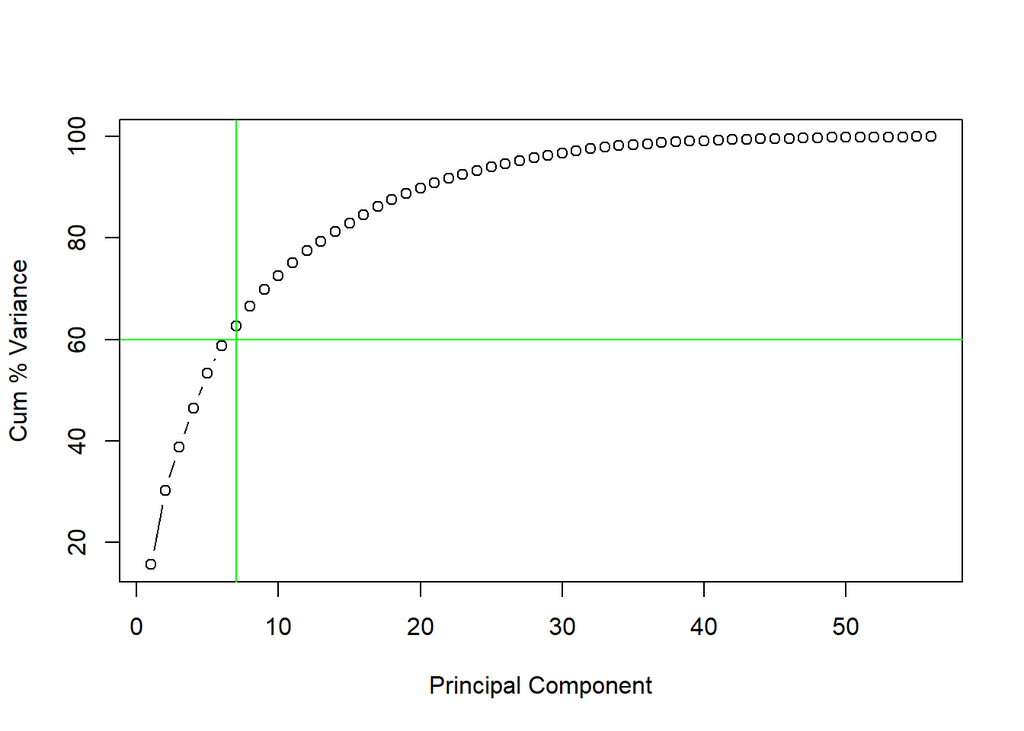

Based on the curve we can see that 60% of the variance can be described in the first 7 PCAs. I decided to use this no. for the model and see if I need to add to it later. This will reduce computation resources required.

## Expected Sample Error

So now it is time to fit and test the model. For the purposes of this exercise I opted for Random Forest classification tree approach. I tried the rpart library to use a basic classification tree. However, accuracy was only 67% when validated against the test sub-dataset. Linear modeling and GLM models are also not suitable for this type of classifiction problem.

```
## Confusion Matrix and Statistics
##
##           Reference
## Prediction    A    B    C    D    E
##          A 1348   17   20   13    0
##          B   32  856   33    9    4
##          C   15   26  781   23   13
##          D    7    6   48  745   13
##          E   10   13   18   15  839
##
## Overall Statistics
##
##                Accuracy : 0.9317
##                  95% CI : (0.9243, 0.9386)
##     No Information Rate : 0.2879
##     P-Value [Acc > NIR] : < 2.2e-16
##
##                   Kappa : 0.9136
##  Mcnemar's Test P-Value : 0.0002668
##
## Statistics by Class:
##
##                      Class: A Class: B Class: C Class: D Class: E
## Sensitivity            0.9547   0.9325   0.8678   0.9255   0.9655
## Specificity            0.9857   0.9804   0.9808   0.9819   0.9861
## Pos Pred Value         0.9642   0.9165   0.9103   0.9096   0.9374
## Neg Pred Value         0.9817   0.9844   0.9706   0.9853   0.9925
## Prevalence             0.2879   0.1872   0.1835   0.1642   0.1772
## Detection Rate         0.2749   0.1746   0.1593   0.1519   0.1711
## Detection Prevalence   0.2851   0.1905   0.1750   0.1670   0.1825
## Balanced Accuracy      0.9702   0.9564   0.9243   0.9537   0.9758
```

## Prediction

You can see that random forrest accuracy on the test subset of data is 93%. Therefore I choose this to use on for the prediction exercise.

The final prediction results on the 20 Observation test dataset is as follows:

```
##  [1] B A A A A E D B A A B C B A E E A B B B
## Levels: A B C D E
```